# Additive Models

2025-10-30

# 4. Detrending and Modeling

GAMMs handle nonlinear responses and can include random effects (e.g., site or tree identity) to account for hierarchical structures and temporal or spatial dependencies, making them well-suited for modeling complex dendrochronological data. in CFSTRenD package, a suite of GAM and GAMM models has been implemented to accommodate different types of datasets. Here, we use one model, gamm_spatial, to demonstrate how to generate a fitting and diagnostic model report.

### **predata and fitting:**

```r
# loading processed ring measurement
samples69.trt <- readRDS(system.file("extdata", "samples69.trt.rds", package = "CFSTRenD"))

# climate
clim69 <- fread(system.file("extdata", "clim69.csv", package = "CFSTRenD"))

samples69_clim <- merge(samples69.trt$tr_all_wide[, c("uid_site", "site_id","latitude", "longitude",  "species", "uid_tree", "uid_radius")], samples69.trt$tr_all_long$tr_7_ring_widths, by = "uid_radius")

# # Calculate BAI
samples69_clim <- calc_bai(samples69_clim, "uid_radius", "rw_mm")

samples69_clim <- merge(samples69_clim, clim69, by = c("site_id", "year"))
```

### **fitting model**

This example uses gamm_spatial, but users may choose other functions (gamm_radius, gamm_site, bam_spatial, gam_mod) that follows the same arguments, according to their purpose and data.

```r
setorder(samples69_clim, uid_tree, year)

# remove the first 10 years, at least remove ageC == 1, for the log-scale model functions
m.sp <- gamm_spatial(data = samples69_clim[ageC > 1], resp_scale = "resp_log",
                     m.candidates =c( "bai_cm2 ~ log(ba_cm2_t_1) + s(ageC) + s(FFD)",
                                      "bai_cm2 ~ log(ba_cm2_t_1) + s(ageC) + FFD")
)
```

### **arguments of gamm_spatial:**

**resp_scale**

**m.candidates**

```r
generate_report(robj = m.sp, output_file = NULL)
```

#### **arguments of the generate_report() function:**

**robj**

The input for the model report is the output of the modelling functions, which assigns the class “cfs_model” to the resulting object.

# Generalized Additive Model Analysis Report

2025-10-30

This report presents the results of a generalized additive model (GAM) analysis.  
The objective is to evaluate predictor contributions, describe the functional forms of relationships,  
and assess the adequacy of the fitted model.  
The following sections include a model summary, smooth term importance, partial effect visualizations,  
and diagnostic checks to ensure the robustness of the analysis.

### Model Summary

The following output provides the summary of the fitted GAM model.  
It includes estimated coefficients, smooth terms, approximate significance of predictors,  
and overall model fit statistics.

```
#>
#> Family: gaussian
#> Link function: identity
#>
#> Formula:
#> log(bai_cm2) ~ log(ba_cm2_t_1) + s(ageC) + s(FFD) + s(uid_site.fac,
#>     bs = "re")
#>
#> Parametric coefficients:
#>                 Estimate Std. Error t value Pr(>|t|)
#> (Intercept)      0.25215    0.15513   1.625    0.104
#> log(ba_cm2_t_1)  0.40518    0.02047  19.793   <2e-16 ***
#> ---
#> Signif. codes:  0 '***' 0.001 '**' 0.01 '*' 0.05 '.' 0.1 ' ' 1
#>
#> Approximate significance of smooth terms:
#>                   edf Ref.df      F  p-value
#> s(ageC)         2.268  2.268 40.834  < 2e-16 ***
#> s(FFD)          5.661  5.661 23.052  < 2e-16 ***
#> s(uid_site.fac) 4.713  6.000  3.582 0.000128 ***
#> ---
#> Signif. codes:  0 '***' 0.001 '**' 0.01 '*' 0.05 '.' 0.1 ' ' 1
#>
#> R-sq.(adj) =  0.621
#>   Scale est. = 0.33723   n = 3029
```

### Importance of Smooth Terms

The relative contribution of predictors is evaluated by calculating the importance percentage of each smooth term, based on **ssq** method. This indicates how much each variable contributes to explaining variation in the response.

Relative importance of smooth terms based on deviance partitioning.

| Term | Score (%) |
| --- | --- |
| s(ageC) | 74.1 |
| s(uid_site.fac) | 24.3 |
| s(FFD) | 1.6 |

### Partial Effects of Smooth Terms

Partial effect plots illustrate the shape of the relationship between the response and each predictor, while holding other predictors constant. These visualizations help identify nonlinear trends and assess whether effects are monotonic, threshold-like, or more complex.

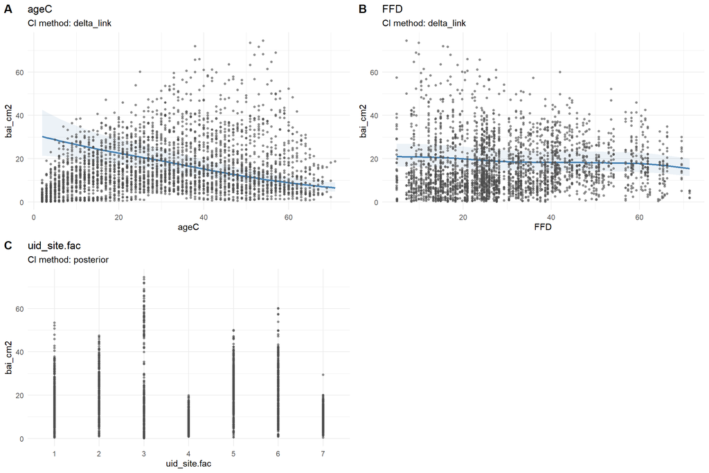

### Model Diagnostics

Diagnostic checks evaluate whether the fitted GAM meets assumptions of independence, normality, and sufficient smoothness. Residuals, k-index, and qq-plots provide evidence of model adequacy or potential overfitting.

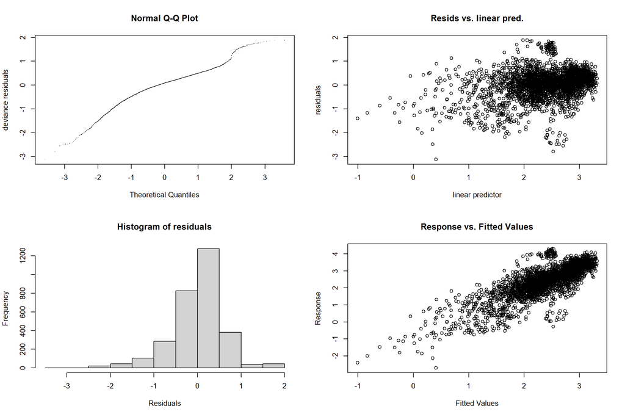

```
#>
#> 'gamm' based fit - care required with interpretation.
#> Checks based on working residuals may be misleading.
#> Basis dimension (k) checking results. Low p-value (k-index<1) may
#> indicate that k is too low, especially if edf is close to k'.
#>
#>                   k'  edf k-index p-value
#> s(ageC)         9.00 2.27    0.89  <2e-16 ***
#> s(FFD)          9.00 5.66    0.83  <2e-16 ***
#> s(uid_site.fac) 7.00 4.71      NA      NA
#> ---
#> Signif. codes:  0 '***' 0.001 '**' 0.01 '*' 0.05 '.' 0.1 ' ' 1
```

# References

- Girardin et al., *CFS-TRenD: A National Tree-Ring Data Repository*, 2021
- Bunn, *Statistical Methods in Dendrochronology*, 2008